# White Wine Quality Analysis by Priyaranjan JC.

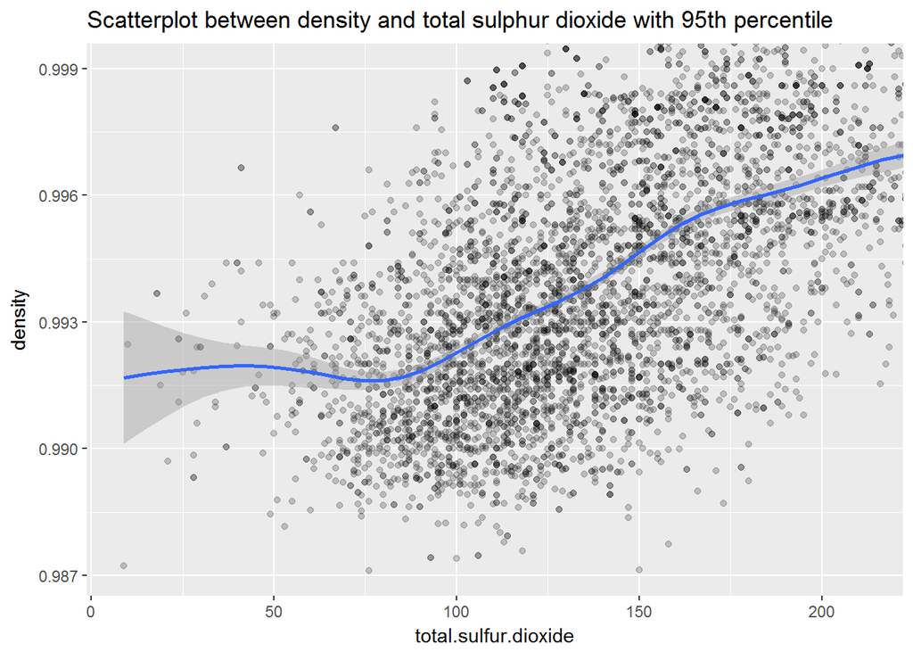

scatter plot between density and total sulphur dioxide with 95th percentile values.

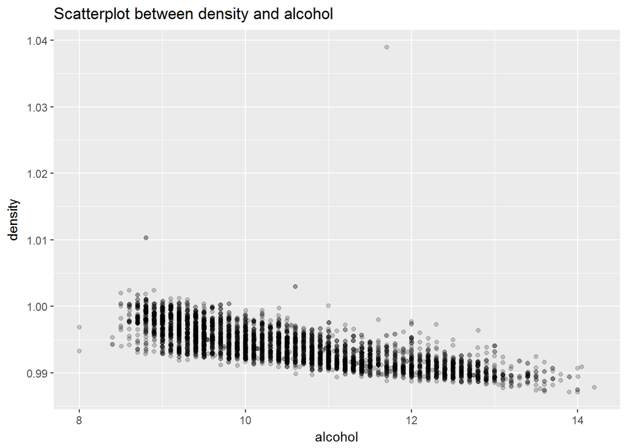

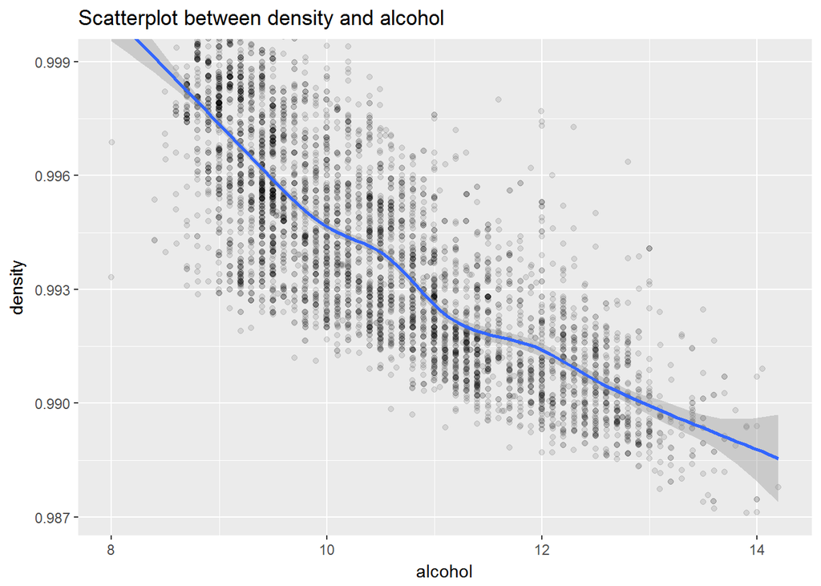

From above graphs we can say there is a negative correlation between alcohol and density.

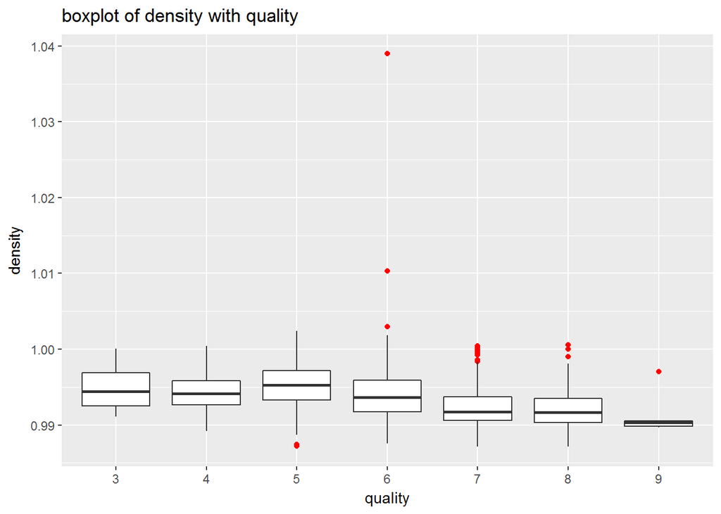

Above Scatterpot show a negative correlation between Density and quality,but its not so prominent.

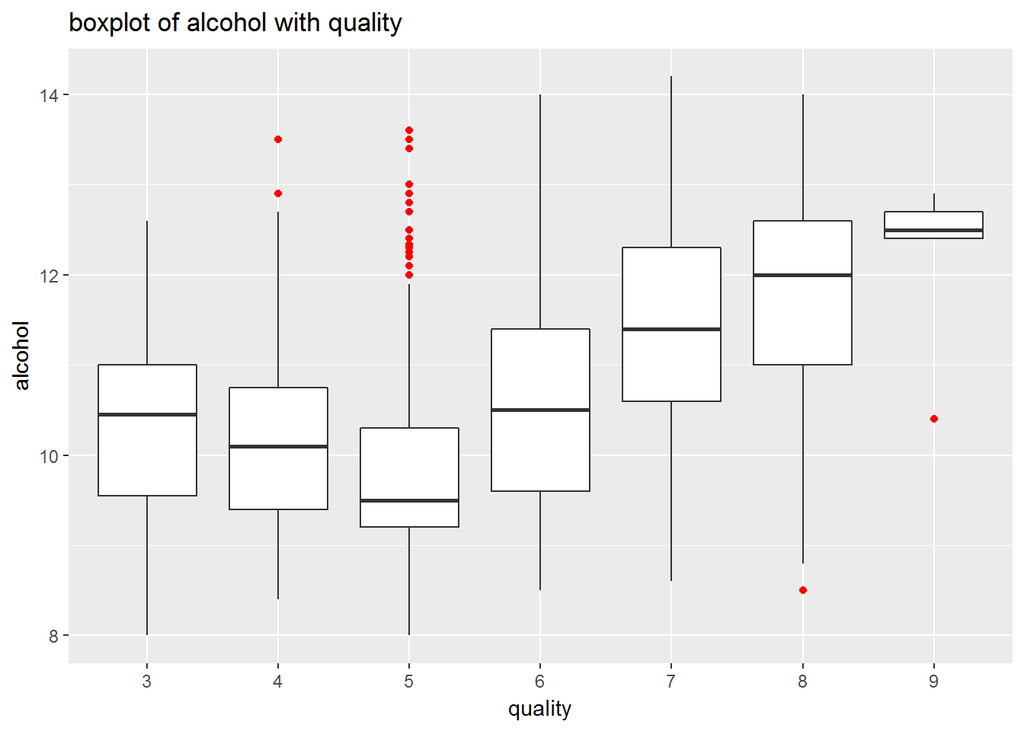

From above plot we can say there is a small positive correlaiton between alcohol and quality.

# Bivariate Analysis

### Talk about some of the relationships you observed in this part of the investigation. How did the feature(s) of interest vary with other features in the dataset?

- There is a small negative correlation between density of the wine and quality of the wine,May be because of the strong positive correlation between residual.sugar and density, wines with high density may tend to be sweeter,which reduces the taste of the wine.
- There is small positive correlation between alcohol and quality of the wine,wines with more alcohol content are preferred to wines with less alcohol content.

### Did you observe any interesting relationships between the other features (not the main feature(s) of interest)?

There is negative correlation between density and alcohol content and positive relation between density and residual sugar.As sugar content increases density increases or if alcohol(poportinal to water content) increases density decreases. When compared to fixed acidity values,volatile acidity values are prettyy less and does not have great impact on overall pH of the wine. Fixed acidity and pH values have negative correlation.

### What was the strongest relationship you found?

Wines residual sugar and density of the wine has a really strong positive correlaiton ship.There is a +0.84 between these variables.

# Multivariate Analysis

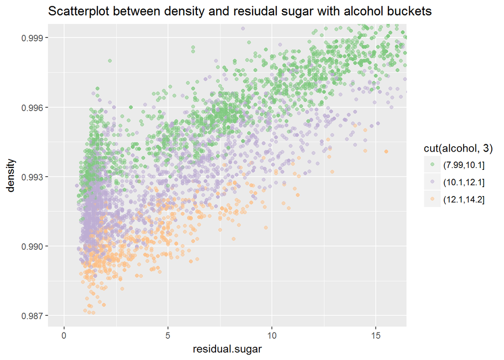